# Stream Water Quality Monitoring

Marc Los Huertos

EA030 · Compiled 2026-04-24

EA030 — RTricks — Activity 06

# Stream Water Quality: Inland Empire Watershed Monitoring

**Prof. Marc Los Huertos** • Pomona College • Environmental Analysis

← Back to RTricks

Context Setup & Data Explore Exceedances E. coli Nutrients Trends ANOVA Risk Model Summary

#### 🎯 Learning Outcomes

1. Build and quality-check a multi-site, multi-parameter water quality dataset.
2. Apply EPA and California Basin Plan regulatory thresholds to classify measurements as exceeding or compliant.
3. Visualise *E. coli* and nutrient concentrations relative to standards across four Southern California streams.
4. Run a Seasonal Kendall trend test to detect long-term water quality trends while controlling for seasonality.
5. Compare mean concentrations across sites with one-way ANOVA and Tukey HSD post-hoc tests.
6. Model the probability of a regulatory exceedance as a function of site and season using logistic regression.
7. Interpret results in the context of land use, urban runoff, and environmental justice in the Inland Empire.

> **What this activity covers.** The streams draining the San Gabriel and San Bernardino Mountains through the Inland Empire — San Antonio Creek, Santa Ana River, San Dimas Creek, and San Gabriel River — receive runoff from a mixture of undeveloped mountain headwaters, suburban sprawl, dairy operations, golf courses, and treated wastewater effluent. This produces complex, spatially variable water quality: some sites regularly exceed bacterial contact standards; others show elevated nutrients from fertiliser and septic inputs. Using simulated but ecologically realistic monitoring data, you will apply the full toolkit of environmental water quality analysis: exceedance mapping, trend detection, ANOVA, and logistic regression for risk modelling.

## 1. Study System and Context

### 1.1 The four streams

SAC

San Antonio Creek

Drains Mt. Baldy; highly seasonal. Upper reaches are pristine; lower reaches receive dairy and residential runoff near Pomona.

SAR

Santa Ana River

Largest river in Southern California. Heavily regulated; receives treated wastewater from multiple plants. Nutrient-rich year-round.

SDC

San Dimas Creek

Urbanised watershed; flows through San Dimas and La Verne. Bacterial contamination follows storm events closely.

SGR

San Gabriel River

Mixed montane and urban inputs; San Gabriel Reservoir provides some attenuation. Golf course and turf runoff elevates nitrogen in lower reaches.

### 1.2 Parameters and regulatory standards

| Parameter | Units | Standard | Regulation | Context |
| --- | --- | --- | --- | --- |
| *E. coli* | MPN/100 mL | 320 (single sample) | CA Basin Plan contact recreation | Above 320 triggers beach/swim closures |
| Nitrate (NO₃⁻) | mg/L as N | 10 | EPA MCL for drinking water | Also an eutrophication driver at lower levels |
| Nitrite (NO₂⁻) | mg/L as N | 1 | EPA MCL | Short-lived; indicates active nitrification |
| Total Phosphorus | µg/L | 100 | CA Basin Plan (reference) | Eutrophication driver; no federal MCL |
| Specific Conductance | µS/cm | 1600 | CA Basin Plan (freshwater) | Salinity proxy; elevated by wastewater and urban runoff |

**📌 Why these four streams?** Together they represent a gradient of land use and water management: San Antonio Creek (mostly natural headwaters), San Dimas Creek (dense suburban), Santa Ana River (managed / wastewater-dominated), and San Gabriel River (mixed). Comparing them lets you attribute water quality patterns to underlying watershed processes rather than site-specific anomalies.

## 2. Setup and Simulated Data

### 2.1 Packages

```r
library(tidyverse)
library(lubridate)
library(trend)       # Seasonal Kendall test
library(broom)       # tidy() model output
library(knitr)
library(kableExtra)
```

### 2.2 EPA / Basin Plan standards

```r
standards <- tibble(
  parameter  = c("ecoli", "nitrate_n", "nitrite_n",
                 "tp_ug_l", "conductance"),
  threshold  = c(320,  10,   1,    100,  1600),
  units      = c("MPN/100 mL", "mg/L as N", "mg/L as N",
                 "µg/L",       "µS/cm"),
  regulation = c("CA Basin Plan (REC-1)", "EPA MCL", "EPA MCL",
                 "CA Basin Plan", "CA Basin Plan"),
  stringsAsFactors = FALSE
)

standards %>%
  kbl(caption = "Regulatory thresholds used in this analysis") %>%
  kable_styling(bootstrap_options = c("striped","hover"), full_width = FALSE)
```

Regulatory thresholds used in this analysis

| parameter | threshold | units | regulation | stringsAsFactors |
| --- | --- | --- | --- | --- |
| ecoli | 320 | MPN/100 mL | CA Basin Plan (REC-1) | FALSE |
| nitrate_n | 10 | mg/L as N | EPA MCL | FALSE |
| nitrite_n | 1 | mg/L as N | EPA MCL | FALSE |
| tp_ug_l | 100 | µg/L | CA Basin Plan | FALSE |
| conductance | 1600 | µS/cm | CA Basin Plan | FALSE |

### 2.3 Simulate monitoring data

```r
set.seed(2024)

# ── Site definitions ──────────────────────────────────────────────────────────
sites <- tribble(
  ~stream,             ~station,   ~position,    ~land_use,
  "San Antonio Creek", "SAC-UP",   "upstream",   "natural",
  "San Antonio Creek", "SAC-DN",   "downstream", "mixed_ag",
  "Santa Ana River",   "SAR-UP",   "upstream",   "mixed_ag",
  "Santa Ana River",   "SAR-DN",   "downstream", "wastewater",
  "San Dimas Creek",   "SDC-UP",   "upstream",   "suburban",
  "San Dimas Creek",   "SDC-DN",   "downstream", "urban",
  "San Gabriel River", "SGR-UP",   "upstream",   "natural",
  "San Gabriel River", "SGR-DN",   "downstream", "suburban"
)

# ── Parameter means by land-use type ─────────────────────────────────────────
# ecoli (log-normal MPN), nitrate_n (mg/L N), tp_ug_l (µg/L),
# conductance (µS/cm), nitrite_n (mg/L N)
lu_params <- tribble(
  ~land_use,     ~ec_mu, ~ec_sd, ~no3_mu, ~no3_sd, ~tp_mu, ~tp_sd, ~cond_mu, ~cond_sd, ~no2_mu, ~no2_sd,
  "natural",      3.5,   1.0,    0.30,   0.20,    20,    8,     180,    40,    0.02,  0.02,
  "mixed_ag",     4.2,   1.1,    3.50,   1.20,    80,   30,     480,   120,    0.12,  0.08,
  "suburban",     4.8,   1.2,    5.00,   1.50,   110,   40,     650,   150,    0.20,  0.12,
  "urban",        5.5,   1.3,    7.50,   2.00,   160,   60,     900,   200,    0.35,  0.18,
  "wastewater",   4.0,   0.9,   12.00,   2.50,   380,   80,    1400,   250,    0.80,  0.30
)

# ── Generate monthly records 2014-2023 ────────────────────────────────────────
dates <- seq(ymd("2014-01-01"), ymd("2023-12-01"), by = "month")

wq <- sites %>%
  left_join(lu_params, by = "land_use") %>%
  crossing(date = dates) %>%
  mutate(
    mo       = month(date),
    yr       = year(date),
    # Seasonal multipliers: wet season (Dec-Mar) boosts bacteria; summer reduces flow
    wet      = mo %in% c(12, 1, 2, 3),
    dry      = mo %in% c(7, 8, 9),
    # E. coli: log-normal; storm events in wet season inflate counts
    ecoli    = round(rlnorm(n(), ec_mu + wet * 0.9 - dry * 0.3, ec_sd)),
    # Nitrate: log-normal; slightly higher in wet season (flushing)
    nitrate_n = pmax(0.01, rlnorm(n(), log(no3_mu) + wet * 0.2, no3_sd / no3_mu)),
    # Nitrite: log-normal
    nitrite_n = pmax(0.001, rlnorm(n(), log(no2_mu + 0.001), no2_sd / (no2_mu + 0.001))),
    # Total phosphorus
    tp_ug_l   = pmax(1, rnorm(n(), tp_mu + wet * 15 - dry * 5, tp_sd)),
    # Conductance: higher in summer (concentration effect) and wastewater reaches
    conductance = pmax(50, rnorm(n(), cond_mu - wet * 80 + dry * 100, cond_sd)),
    # Exceedance flags
    exc_ecoli  = ecoli     > 320,
    exc_no3    = nitrate_n > 10,
    exc_no2    = nitrite_n > 1,
    exc_tp     = tp_ug_l   > 100,
    exc_cond   = conductance > 1600,
    season     = case_when(
      mo %in% c(12, 1, 2)  ~ "Winter",
      mo %in% c(3, 4, 5)   ~ "Spring",
      mo %in% c(6, 7, 8)   ~ "Summer",
      TRUE                  ~ "Fall"
    ),
    season = factor(season, levels = c("Winter", "Spring", "Summer", "Fall"))
  ) %>%
  select(stream, station, position, land_use, date, yr, mo, season,
         ecoli, nitrate_n, nitrite_n, tp_ug_l, conductance,
         exc_ecoli, exc_no3, exc_no2, exc_tp, exc_cond)

glimpse(wq)
```

```
## Rows: 960
## Columns: 18
## $ stream      <chr> "San Antonio Creek", "San Antonio Creek", "San Antonio Cre…
## $ station     <chr> "SAC-DN", "SAC-DN", "SAC-DN", "SAC-DN", "SAC-DN", "SAC-DN"…
## $ position    <chr> "downstream", "downstream", "downstream", "downstream", "d…
## $ land_use    <chr> "mixed_ag", "mixed_ag", "mixed_ag", "mixed_ag", "mixed_ag"…
## $ date        <date> 2014-01-01, 2014-02-01, 2014-03-01, 2014-04-01, 2014-05-0…
## $ yr          <dbl> 2014, 2014, 2014, 2014, 2014, 2014, 2014, 2014, 2014, 2014…
## $ mo          <dbl> 1, 2, 3, 4, 5, 6, 7, 8, 9, 10, 11, 12, 1, 2, 3, 4, 5, 6, 7…
## $ season      <fct> Winter, Winter, Spring, Spring, Spring, Summer, Summer, Su…
## $ ecoli       <dbl> 483, 275, 146, 53, 238, 276, 89, 43, 13, 19, 11, 275, 410,…
## $ nitrate_n   <dbl> 6.128798, 3.238294, 5.485123, 1.812692, 2.977360, 3.110879…
## $ nitrite_n   <dbl> 0.19295760, 0.07155427, 0.11001378, 0.05362045, 0.05660624…
## $ tp_ug_l     <dbl> 64.96573, 111.72904, 105.39678, 119.88122, 40.80809, 47.32…
## $ conductance <dbl> 367.3207, 528.5351, 453.7448, 435.9880, 703.0057, 663.2351…
## $ exc_ecoli   <lgl> TRUE, FALSE, FALSE, FALSE, FALSE, FALSE, FALSE, FALSE, FAL…
## $ exc_no3     <lgl> FALSE, FALSE, FALSE, FALSE, FALSE, FALSE, FALSE, FALSE, FA…
## $ exc_no2     <lgl> FALSE, FALSE, FALSE, FALSE, FALSE, FALSE, FALSE, FALSE, FA…
## $ exc_tp      <lgl> FALSE, TRUE, TRUE, TRUE, FALSE, FALSE, FALSE, TRUE, TRUE, …
## $ exc_cond    <lgl> FALSE, FALSE, FALSE, FALSE, FALSE, FALSE, FALSE, FALSE, FA…
```

## 3. Exploratory Overview

### 3.1 Sample counts and summary

```r
wq %>%
  group_by(stream, station, position, land_use) %>%
  summarise(n = n(), .groups = "drop") %>%
  kbl(caption = "Monitoring records per station") %>%
  kable_styling(bootstrap_options = c("striped","hover"), full_width = FALSE)
```

Monitoring records per station

| stream | station | position | land_use | n |
| --- | --- | --- | --- | --- |
| San Antonio Creek | SAC-DN | downstream | mixed_ag | 120 |
| San Antonio Creek | SAC-UP | upstream | natural | 120 |
| San Dimas Creek | SDC-DN | downstream | urban | 120 |
| San Dimas Creek | SDC-UP | upstream | suburban | 120 |
| San Gabriel River | SGR-DN | downstream | suburban | 120 |
| San Gabriel River | SGR-UP | upstream | natural | 120 |
| Santa Ana River | SAR-DN | downstream | wastewater | 120 |
| Santa Ana River | SAR-UP | upstream | mixed_ag | 120 |

### 3.2 Distribution of key parameters across stations

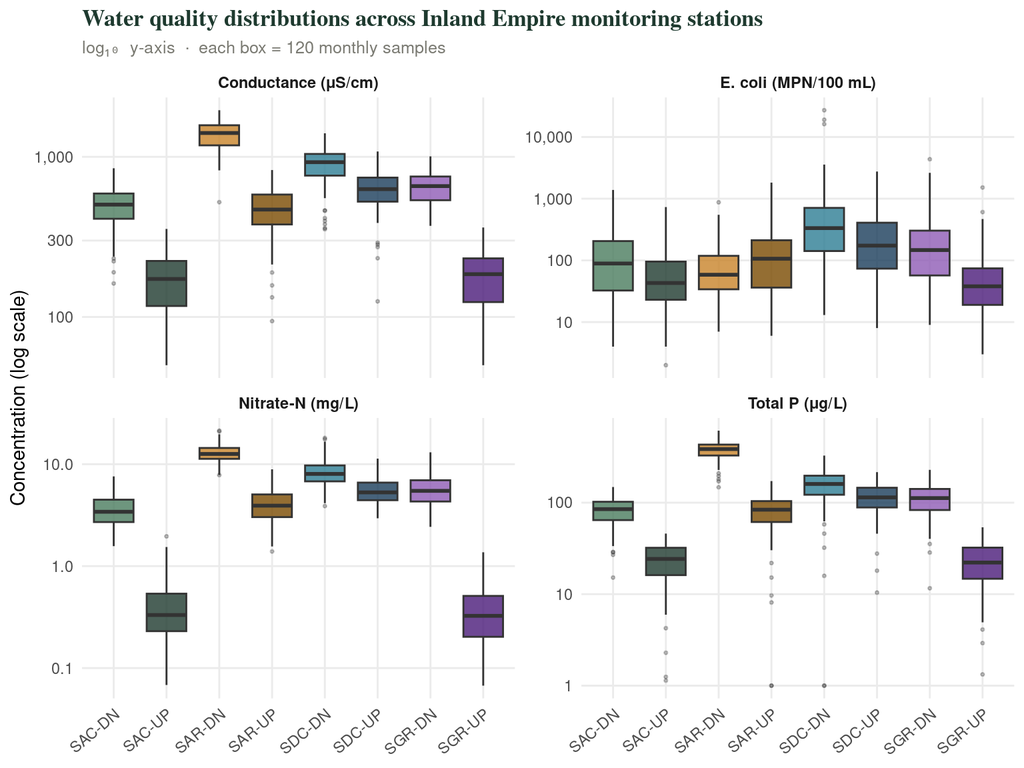

```r
site_colors <- c(
  "SAC-UP" = "#1e3a2f", "SAC-DN" = "#4a7c5e",
  "SAR-UP" = "#7a4a00", "SAR-DN" = "#c8832a",
  "SDC-UP" = "#1a3d5a", "SDC-DN" = "#2e7d94",
  "SGR-UP" = "#4a1b7a", "SGR-DN" = "#8e5cb5"
)

wq %>%
  pivot_longer(c(ecoli, nitrate_n, tp_ug_l, conductance),
               names_to = "parameter", values_to = "value") %>%
  mutate(parameter = recode(parameter,
    "ecoli"       = "E. coli (MPN/100 mL)",
    "nitrate_n"   = "Nitrate-N (mg/L)",
    "tp_ug_l"     = "Total P (\u03bcg/L)",
    "conductance" = "Conductance (\u03bcS/cm)"
  )) %>%
  ggplot(aes(x = station, y = value, fill = station)) +
  geom_boxplot(outlier.size = 0.6, outlier.alpha = 0.3,
               alpha = 0.8, show.legend = FALSE) +
  scale_fill_manual(values = site_colors) +
  scale_y_log10(labels = scales::comma) +
  facet_wrap(~ parameter, scales = "free_y", ncol = 2) +
  scale_x_discrete(guide = guide_axis(angle = 40)) +
  labs(
    title    = "Water quality distributions across Inland Empire monitoring stations",
    subtitle = "log\u2081\u2080 y-axis  \u00b7  each box = 120 monthly samples",
    x = NULL, y = "Concentration (log scale)"
  ) +
  theme_minimal(base_size = 11) +
  theme(
    plot.title    = element_text(family = "serif", face = "bold",
                                 color = "#1e3a2f", size = 13),
    plot.subtitle = element_text(color = "#7a7a72", size = 9.5),
    strip.text    = element_text(face = "bold"),
    panel.grid.minor = element_blank()
  )
```

## 4. Regulatory Exceedance Analysis

### 4.1 Exceedance rates by station

```r
exc_summary <- wq %>%
  group_by(stream, station, land_use) %>%
  summarise(
    n          = n(),
    pct_ecoli  = round(100 * mean(exc_ecoli), 1),
    pct_no3    = round(100 * mean(exc_no3),   1),
    pct_tp     = round(100 * mean(exc_tp),    1),
    pct_cond   = round(100 * mean(exc_cond),  1),
    .groups    = "drop"
  ) %>%
  arrange(stream, station)

exc_summary %>%
  kbl(
    caption   = "Percent of monthly samples exceeding regulatory thresholds by station",
    col.names = c("Stream", "Station", "Land use", "N",
                  "E. coli >320", "NO\u2083-N >10 mg/L",
                  "Total P >100 µg/L", "Cond >1600 µS/cm")
  ) %>%
  kable_styling(bootstrap_options = c("striped","hover"), full_width = FALSE) %>%
  row_spec(which(exc_summary$pct_ecoli > 20), bold = TRUE,
           background = "#fff5f5")
```

Percent of monthly samples exceeding regulatory thresholds by station

| Stream | Station | Land use | N | E. coli >320 | NO₃-N >10 mg/L | Total P >100 µg/L | Cond >1600 µS/cm |
| --- | --- | --- | --- | --- | --- | --- | --- |
| San Antonio Creek | SAC-DN | mixed_ag | 120 | 11.7 | 0.0 | 29.2 | 0.0 |
| San Antonio Creek | SAC-UP | natural | 120 | 3.3 | 0.0 | 0.0 | 0.0 |
| San Dimas Creek | SDC-DN | urban | 120 | 50.8 | 21.7 | 80.8 | 0.0 |
| San Dimas Creek | SDC-UP | suburban | 120 | 29.2 | 3.3 | 63.3 | 0.0 |
| San Gabriel River | SGR-DN | suburban | 120 | 23.3 | 5.0 | 62.5 | 0.0 |
| San Gabriel River | SGR-UP | natural | 120 | 5.0 | 0.0 | 0.0 | 0.0 |
| Santa Ana River | SAR-DN | wastewater | 120 | 5.0 | 86.7 | 100.0 | 21.7 |
| Santa Ana River | SAR-UP | mixed_ag | 120 | 19.2 | 0.0 | 32.5 | 0.0 |

### 4.2 Exceedance heatmap

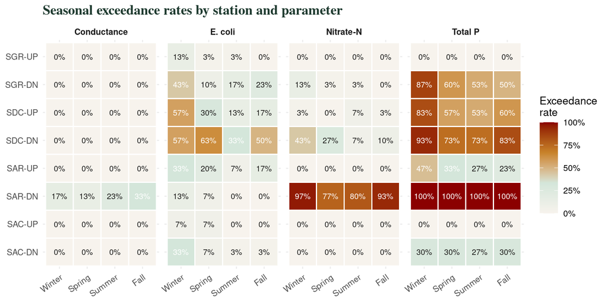

```r
exc_long <- wq %>%
  group_by(stream, station, season) %>%
  summarise(
    `E. coli`   = mean(exc_ecoli),
    `Nitrate-N` = mean(exc_no3),
    `Total P`   = mean(exc_tp),
    Conductance = mean(exc_cond),
    .groups = "drop"
  ) %>%
  pivot_longer(c("E. coli","Nitrate-N","Total P","Conductance"),
               names_to = "parameter", values_to = "exc_rate")

ggplot(exc_long, aes(x = season, y = station, fill = exc_rate)) +
  geom_tile(color = "white", linewidth = 0.5) +
  geom_text(aes(label = scales::percent(exc_rate, accuracy = 1)),
            size = 2.6, color = ifelse(exc_long$exc_rate > 0.3, "white", "#1a1a18")) +
  scale_fill_gradientn(
    colors = c("#f7f3ed", "#d4e6da", "#c8832a", "#8b0000"),
    limits = c(0, 1),
    labels = scales::percent_format(),
    name   = "Exceedance\nrate"
  ) +
  facet_wrap(~ parameter, nrow = 1) +
  labs(
    title    = "Seasonal exceedance rates by station and parameter",
    x = NULL, y = NULL
  ) +
  theme_minimal(base_size = 10) +
  theme(
    plot.title  = element_text(family = "serif", face = "bold",
                               color = "#1e3a2f", size = 13),
    strip.text  = element_text(face = "bold"),
    axis.text.x = element_text(angle = 35, hjust = 1)
  )
```

## 5. *E. coli* Deep Dive

### 5.1 Time series relative to contact recreation standard

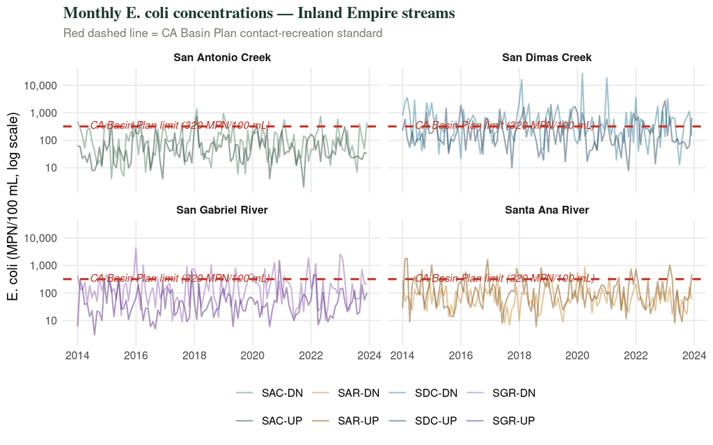

```r
wq %>%
  ggplot(aes(x = date, y = ecoli, color = station)) +
  geom_line(alpha = 0.45, linewidth = 0.55) +
  geom_hline(yintercept = 320, linetype = "dashed",
             color = "#c0392b", linewidth = 0.8) +
  annotate("text", x = ymd("2014-06-01"), y = 360,
           label = "CA Basin Plan limit (320 MPN/100 mL)",
           color = "#c0392b", size = 3, hjust = 0, fontface = "italic") +
  scale_y_log10(labels = scales::comma) +
  scale_color_manual(values = site_colors, name = NULL) +
  facet_wrap(~ stream, ncol = 2) +
  labs(
    title    = "Monthly E. coli concentrations — Inland Empire streams",
    subtitle = "Red dashed line = CA Basin Plan contact-recreation standard",
    x = NULL, y = "E. coli (MPN/100 mL, log scale)"
  ) +
  theme_minimal(base_size = 11) +
  theme(
    plot.title    = element_text(family = "serif", face = "bold",
                                 color = "#1e3a2f", size = 13),
    plot.subtitle = element_text(color = "#7a7a72", size = 9.5),
    legend.position = "bottom",
    strip.text    = element_text(face = "bold"),
    panel.grid.minor = element_blank()
  )
```

### 5.2 Seasonal *E. coli* patterns

Wet-season storm runoff mobilises fecal bacteria from urban surfaces, livestock areas, and failing septic systems. The seasonal signal is strongest in urban and agricultural catchments.

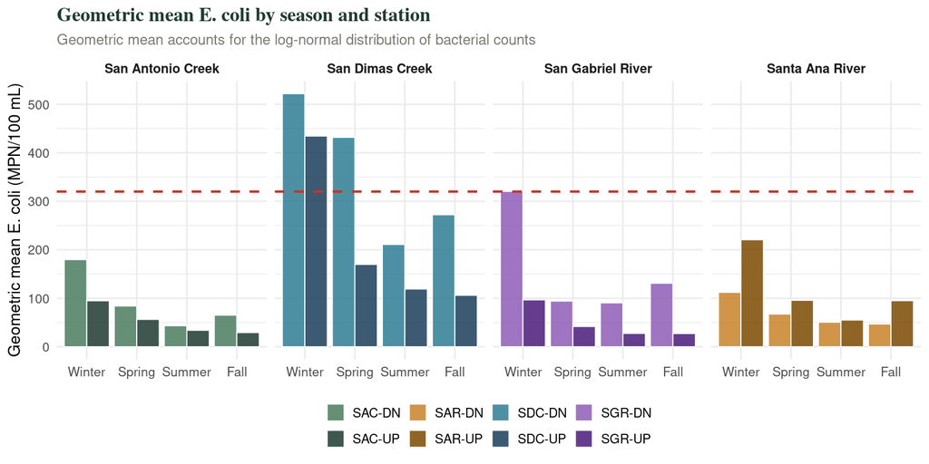

```r
wq %>%
  group_by(station, stream, season) %>%
  summarise(
    gm_ecoli = exp(mean(log(ecoli + 1))),  # geometric mean
    .groups  = "drop"
  ) %>%
  ggplot(aes(x = season, y = gm_ecoli, fill = station)) +
  geom_col(position = "dodge", color = "white", linewidth = 0.3, alpha = 0.85) +
  geom_hline(yintercept = 320, linetype = "dashed",
             color = "#c0392b", linewidth = 0.7) +
  scale_fill_manual(values = site_colors, name = NULL) +
  scale_y_continuous(labels = scales::comma) +
  facet_wrap(~ stream, nrow = 1) +
  labs(
    title    = "Geometric mean E. coli by season and station",
    subtitle = "Geometric mean accounts for the log-normal distribution of bacterial counts",
    x = NULL, y = "Geometric mean E. coli (MPN/100 mL)"
  ) +
  theme_minimal(base_size = 10) +
  theme(
    plot.title    = element_text(family = "serif", face = "bold",
                                 color = "#1e3a2f", size = 12),
    plot.subtitle = element_text(color = "#7a7a72", size = 9),
    strip.text    = element_text(face = "bold"),
    legend.position = "bottom",
    legend.key.size = unit(0.4, "cm")
  )
```

**📌 Why geometric mean for bacteria?** *E. coli* counts follow a log-normal distribution — a few extreme values can be 100× the typical reading. The arithmetic mean is heavily influenced by outliers and overestimates the central tendency of bacterial exposure. The geometric mean (= exp(mean(log(x)))) is the standard central-tendency measure used in Basin Plan assessments for contact recreation standards.

## 6. Nutrient Analysis

### 6.1 Nitrate and total phosphorus distributions

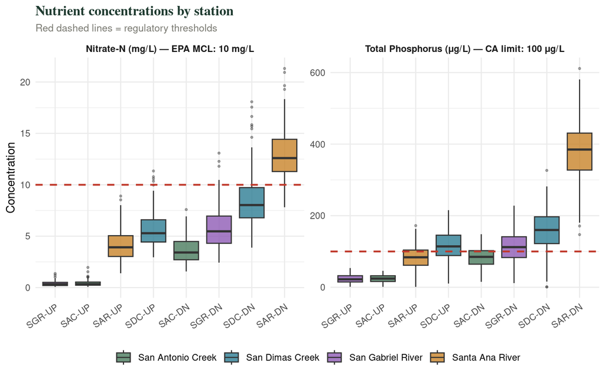

```r
wq %>%
  pivot_longer(c(nitrate_n, tp_ug_l),
               names_to = "parameter", values_to = "value") %>%
  mutate(
    parameter = recode(parameter,
      "nitrate_n" = "Nitrate-N (mg/L) — EPA MCL: 10 mg/L",
      "tp_ug_l"   = "Total Phosphorus (\u03bcg/L) — CA limit: 100 \u03bcg/L"
    ),
    threshold = if_else(grepl("Nitrate", parameter), 10, 100)
  ) %>%
  ggplot(aes(x = reorder(station, value, median), y = value, fill = stream)) +
  geom_boxplot(alpha = 0.8, outlier.size = 0.7, outlier.alpha = 0.4) +
  geom_hline(aes(yintercept = threshold), linetype = "dashed",
             color = "#c0392b", linewidth = 0.8) +
  scale_fill_manual(
    values = c(
      "San Antonio Creek" = "#4a7c5e",
      "Santa Ana River"   = "#c8832a",
      "San Dimas Creek"   = "#2e7d94",
      "San Gabriel River" = "#8e5cb5"
    ),
    name = NULL
  ) +
  scale_x_discrete(guide = guide_axis(angle = 35)) +
  facet_wrap(~ parameter, scales = "free_y") +
  labs(
    title = "Nutrient concentrations by station",
    subtitle = "Red dashed lines = regulatory thresholds",
    x = NULL, y = "Concentration"
  ) +
  theme_minimal(base_size = 11) +
  theme(
    plot.title    = element_text(family = "serif", face = "bold",
                                 color = "#1e3a2f", size = 13),
    plot.subtitle = element_text(color = "#7a7a72", size = 9.5),
    strip.text    = element_text(face = "bold"),
    legend.position = "bottom"
  )
```

### 6.2 N:P ratio and eutrophication risk

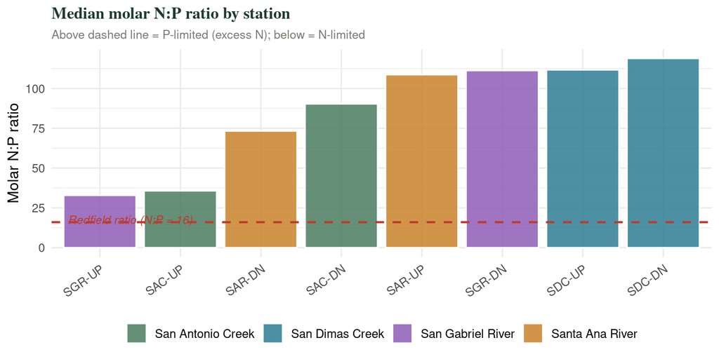

```r
wq %>%
  mutate(
    # Convert to molar: N/14 and P/31 (converting µg/L to mg/L first for P)
    N_molar = nitrate_n / 14,
    P_molar = (tp_ug_l / 1000) / 31,
    NP_ratio = N_molar / P_molar
  ) %>%
  group_by(station, stream) %>%
  summarise(median_NP = median(NP_ratio, na.rm = TRUE), .groups = "drop") %>%
  ggplot(aes(x = reorder(station, median_NP), y = median_NP, fill = stream)) +
  geom_col(alpha = 0.85, color = "white") +
  geom_hline(yintercept = 16, linetype = "dashed",
             color = "#c0392b", linewidth = 0.8) +
  annotate("text", x = 0.6, y = 17.5,
           label = "Redfield ratio (N:P = 16)",
           color = "#c0392b", hjust = 0, size = 3.2, fontface = "italic") +
  scale_fill_manual(
    values = c("San Antonio Creek" = "#4a7c5e", "Santa Ana River" = "#c8832a",
               "San Dimas Creek" = "#2e7d94",   "San Gabriel River" = "#8e5cb5"),
    name = NULL
  ) +
  scale_x_discrete(guide = guide_axis(angle = 35)) +
  labs(
    title    = "Median molar N:P ratio by station",
    subtitle = "Above dashed line = P-limited (excess N); below = N-limited",
    x = NULL, y = "Molar N:P ratio"
  ) +
  theme_minimal(base_size = 12) +
  theme(
    plot.title    = element_text(family = "serif", face = "bold",
                                 color = "#1e3a2f", size = 13),
    plot.subtitle = element_text(color = "#7a7a72", size = 9.5),
    legend.position = "bottom"
  )
```

## 7. Trend Detection — Seasonal Kendall Test

The **Seasonal Kendall test** (Hirsch et al. 1982) tests for a monotonic trend in a time series while controlling for seasonal effects. It is the standard method for environmental monitoring data because it is non-parametric (no normality assumption) and handles the strong seasonal cycles typical of stream chemistry.

**⚙️ How the Seasonal Kendall test works.** The Mann-Kendall statistic S counts the number of concordant minus discordant pairs in the data. The Seasonal Kendall version computes S separately within each season (month), then sums across seasons. This removes the seasonal signal before testing for trend, so a winter that is consistently higher than summer does not appear as a trend.

```r
library(trend)

# Apply Seasonal Kendall to log(E. coli) at each station
sk_results <- wq %>%
  group_by(station, stream) %>%
  arrange(date) %>%
  group_modify(~ {
    x   <- log(.x$ecoli + 1)
    mon <- .x$mo
    tryCatch({
      res <- seaken(x, mon)
      tibble(
        S        = res$S,
        tau      = round(res$tau,   3),
        p_value  = round(res$p.value, 4),
        trend    = case_when(
          res$p.value < 0.05 & res$tau > 0 ~ "Increasing",
          res$p.value < 0.05 & res$tau < 0 ~ "Decreasing",
          TRUE                              ~ "No trend"
        )
      )
    }, error = function(e) tibble(S=NA, tau=NA, p_value=NA, trend="Error"))
  }) %>%
  ungroup()

sk_results %>%
  kbl(
    caption   = "Seasonal Kendall trend test results for log(E. coli + 1), 2014–2023",
    col.names = c("Station", "Stream", "S statistic", "\u03c4 (tau)", "p-value", "Trend")
  ) %>%
  kable_styling(bootstrap_options = c("striped","hover"), full_width = FALSE) %>%
  row_spec(which(sk_results$trend == "Increasing"),
           bold = TRUE, background = "#fff5f5") %>%
  row_spec(which(sk_results$trend == "Decreasing"),
           bold = TRUE, background = "#f1f8f1")
```

Seasonal Kendall trend test results for log(E. coli + 1), 2014–2023

[output not shown]

**💡 Interpreting tau.** Kendall’s τ ranges from −1 (perfectly decreasing) to +1 (perfectly increasing). Values near zero indicate no monotonic trend. A τ of +0.15 with p < 0.05 means there is a statistically significant but weak upward trend — statistically real but possibly not ecologically meaningful. Always consider the magnitude alongside the p-value.

## 8. ANOVA: Do Sites Differ in Nitrate?

A significant Seasonal Kendall test tells you *whether* a trend exists at each station but not whether stations differ from each other. One-way ANOVA tests whether mean nitrate concentration differs among the eight stations.

### 8.1 Assumption check

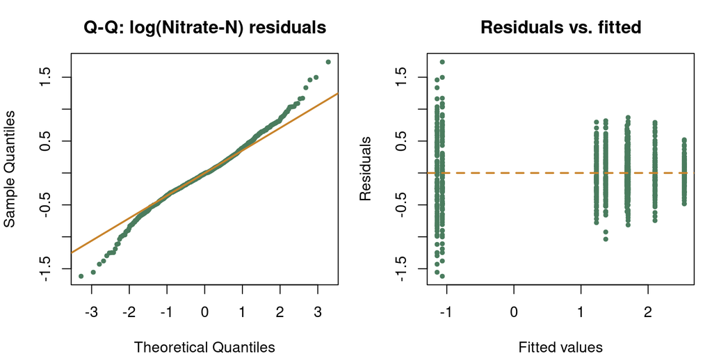

```r
aov_fit <- aov(log(nitrate_n) ~ station, data = wq)

par(mfrow = c(1, 2), mar = c(4, 4, 3, 1))
qqnorm(residuals(aov_fit), main = "Q-Q: log(Nitrate-N) residuals",
       col = "#4a7c5e", pch = 19, cex = 0.6)
qqline(residuals(aov_fit), col = "#c8832a", lwd = 2)
plot(fitted(aov_fit), residuals(aov_fit),
     xlab = "Fitted values", ylab = "Residuals",
     main = "Residuals vs. fitted",
     col = "#4a7c5e", pch = 19, cex = 0.6)
abline(h = 0, col = "#c8832a", lwd = 2, lty = 2)
```

```r
par(mfrow = c(1, 1))
```

```r
car::leveneTest(log(nitrate_n) ~ station, data = wq)
```

```
## Levene's Test for Homogeneity of Variance (center = median)
##        Df F value    Pr(>F)
## group   7  31.177 < 2.2e-16 ***
##       952
## ---
## Signif. codes:  0 '***' 0.001 '**' 0.01 '*' 0.05 '.' 0.1 ' ' 1
```

### 8.2 ANOVA and Tukey HSD

```r
summary(aov_fit)
```

```
##              Df Sum Sq Mean Sq F value Pr(>F)
## station       7 1630.3  232.90    1362 <2e-16 ***
## Residuals   952  162.9    0.17
## ---
## Signif. codes:  0 '***' 0.001 '**' 0.01 '*' 0.05 '.' 0.1 ' ' 1
```

```r
tukey_res <- TukeyHSD(aov_fit)

tukey_tbl <- broom::tidy(tukey_res) %>%
  select(contrast, estimate, conf.low, conf.high, adj.p.value) %>%
  mutate(across(where(is.numeric), ~ round(.x, 3))) %>%
  filter(adj.p.value < 0.05) %>%
  arrange(adj.p.value)

cat("Significant pairwise differences (FDR-adjusted p < 0.05):", nrow(tukey_tbl), "\n")
```

```
## Significant pairwise differences (FDR-adjusted p < 0.05): 25
```

```r
tukey_tbl %>%
  head(12) %>%
  kbl(
    caption   = "Top 12 significant Tukey HSD comparisons — log(Nitrate-N)",
    col.names = c("Comparison", "Difference (log scale)",
                  "Lower CI", "Upper CI", "Adj. p-value")
  ) %>%
  kable_styling(bootstrap_options = c("striped","hover"), full_width = FALSE)
```

Top 12 significant Tukey HSD comparisons — log(Nitrate-N)

| Comparison | Difference (log scale) | Lower CI | Upper CI | Adj. p-value |
| --- | --- | --- | --- | --- |
| SAC-UP-SAC-DN | -2.297 | -2.459 | -2.135 | 0 |
| SAR-DN-SAC-DN | 1.309 | 1.147 | 1.471 | 0 |
| SDC-DN-SAC-DN | 0.873 | 0.710 | 1.035 | 0 |
| SDC-UP-SAC-DN | 0.456 | 0.293 | 0.618 | 0 |
| SGR-DN-SAC-DN | 0.472 | 0.310 | 0.634 | 0 |
| SGR-UP-SAC-DN | -2.375 | -2.537 | -2.213 | 0 |
| SAR-DN-SAC-UP | 3.606 | 3.444 | 3.768 | 0 |
| SAR-UP-SAC-UP | 2.435 | 2.273 | 2.597 | 0 |
| SDC-DN-SAC-UP | 3.169 | 3.007 | 3.331 | 0 |
| SDC-UP-SAC-UP | 2.752 | 2.590 | 2.915 | 0 |
| SGR-DN-SAC-UP | 2.768 | 2.606 | 2.931 | 0 |
| SAR-UP-SAR-DN | -1.171 | -1.333 | -1.008 | 0 |

## 9. Logistic Regression: Modelling Exceedance Risk

Rather than just describing *where* exceedances occur, we can model the **probability** of an exceedance as a function of predictors. This turns water quality data into a risk management tool.

**Question:** What predicts the probability of an *E. coli* exceedance? We test station identity (as a proxy for land use) and season.

```r
logit_fit <- glm(
  exc_ecoli ~ station + season,
  family  = binomial(link = "logit"),
  data    = wq
)

broom::tidy(logit_fit, exponentiate = TRUE, conf.int = TRUE) %>%
  mutate(across(where(is.numeric), ~ round(.x, 3))) %>%
  kbl(
    caption   = "Logistic regression: odds ratios for E. coli exceedance",
    col.names = c("Term", "Odds ratio", "Std. error",
                  "z-statistic", "p-value", "Lower CI", "Upper CI")
  ) %>%
  kable_styling(bootstrap_options = c("striped","hover"), full_width = FALSE) %>%
  row_spec(which(broom::tidy(logit_fit)$p.value < 0.05), bold = TRUE)
```

Logistic regression: odds ratios for E. coli exceedance

| Term | Odds ratio | Std. error | z-statistic | p-value | Lower CI | Upper CI |
| --- | --- | --- | --- | --- | --- | --- |
| (Intercept) | 0.308 | 0.311 | -3.789 | 0.000 | 0.161 | 0.551 |
| stationSAC-UP | 0.250 | 0.590 | -2.348 | 0.019 | 0.068 | 0.734 |
| stationSAR-DN | 0.385 | 0.515 | -1.854 | 0.064 | 0.130 | 1.015 |
| stationSAR-UP | 1.865 | 0.378 | 1.647 | 0.100 | 0.897 | 3.993 |
| stationSDC-DN | 9.423 | 0.353 | 6.348 | 0.000 | 4.833 | 19.440 |
| stationSDC-UP | 3.401 | 0.361 | 3.393 | 0.001 | 1.709 | 7.084 |
| stationSGR-DN | 2.444 | 0.369 | 2.422 | 0.015 | 1.203 | 5.155 |
| stationSGR-UP | 0.385 | 0.515 | -1.854 | 0.064 | 0.130 | 1.015 |
| seasonSpring | 0.395 | 0.243 | -3.818 | 0.000 | 0.243 | 0.633 |
| seasonSummer | 0.165 | 0.286 | -6.304 | 0.000 | 0.093 | 0.285 |
| seasonFall | 0.263 | 0.260 | -5.138 | 0.000 | 0.156 | 0.434 |

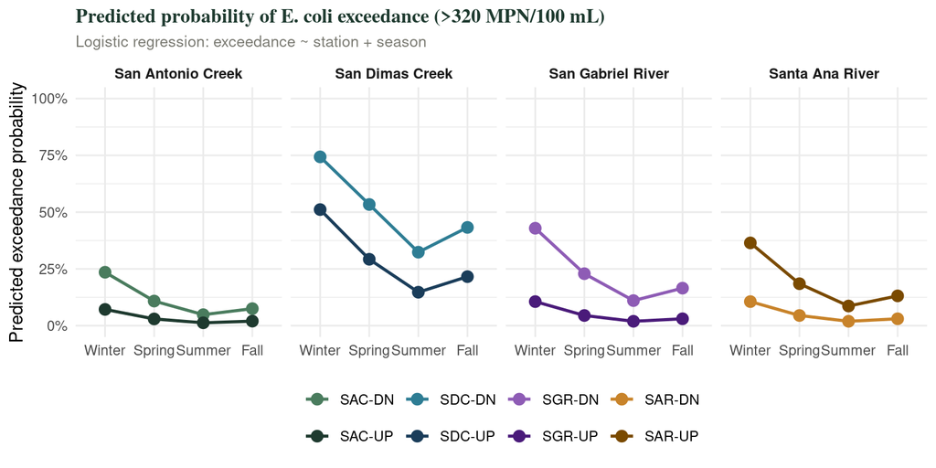

```r
# Predicted exceedance probability by station and season
pred_df <- expand.grid(
  station = unique(wq$station),
  season  = levels(wq$season)
) %>%
  mutate(
    prob_exc = predict(logit_fit, newdata = ., type = "response"),
    stream   = str_extract(station, "SAC|SAR|SDC|SGR") %>%
               recode(SAC = "San Antonio Creek", SAR = "Santa Ana River",
                      SDC = "San Dimas Creek",   SGR = "San Gabriel River")
  )

ggplot(pred_df, aes(x = season, y = prob_exc, color = station, group = station)) +
  geom_line(linewidth = 0.9) +
  geom_point(size = 3) +
  scale_color_manual(values = site_colors, name = NULL) +
  scale_y_continuous(labels = scales::percent_format(), limits = c(0, 1)) +
  facet_wrap(~ stream, nrow = 1) +
  labs(
    title    = "Predicted probability of E. coli exceedance (>320 MPN/100 mL)",
    subtitle = "Logistic regression: exceedance ~ station + season",
    x = NULL, y = "Predicted exceedance probability"
  ) +
  theme_minimal(base_size = 11) +
  theme(
    plot.title    = element_text(family = "serif", face = "bold",
                                 color = "#1e3a2f", size = 12),
    plot.subtitle = element_text(color = "#7a7a72", size = 9.5),
    legend.position = "bottom",
    strip.text    = element_text(face = "bold")
  )
```

## 10. Summary

#### 💡 Key takeaways

- **Land use drives water quality patterns.** Wastewater-influenced Santa Ana River downstream stations show the highest nitrate and phosphorus; urban San Dimas Creek stations show the highest E. coli exceedance rates.
- **Seasonality matters for bacteria, not nutrients.** E. coli concentrations spike in winter with storm runoff. Nitrate and phosphorus from wastewater effluent are elevated year-round.
- **The geometric mean is the correct central tendency for bacteria.** Arithmetic means are inflated by extreme storm events that do not represent typical exposure conditions.
- **The Seasonal Kendall test is the standard for trend detection in water quality data.** It is non-parametric and removes seasonal cycles before testing — essential for data that violates normality and has strong seasonal structure.
- **Logistic regression converts water quality data into risk.** Expressing results as exceedance probabilities is more actionable for managers than reporting raw concentrations.
- **Upstream–downstream pairs reveal human impacts.** Comparing reference (upstream) and impacted (downstream) stations at the same stream controls for climate and hydrology and isolates the land-use signal.

## References

California State Water Resources Control Board. 2022. *Water Quality Control Plan for the Santa Ana River Basin (Basin Plan)*. Region 8. Sacramento, CA.

Hirsch, R. M., Slack, J. R., and Smith, R. A. 1982. Techniques of trend analysis for monthly water quality data. *Water Resources Research* 18:107–121.

US EPA. 1986. *Ambient Water Quality Criteria for Bacteria*. EPA 440/5-84-002.

US EPA. 2012. *Recreational Water Quality Criteria*. EPA 820-F-12-058.

EA030 RTricks | Prof. Marc Los Huertos | Pomona College | Activity 06 | Back to index